# Bank Direct Marketing

Jung

2019-12-07

# 1. Data Understanding

```r
rm(list=ls())
library("tidyverse")
```

## 1.1 Collect Initial Data

```r
# Import bank-full data and save it as bank
bank <- read.csv("bank-full.csv", sep = ';')
bank_svm <- read.csv("bank.csv", sep=";")
```

Notes: 1) bank-full.csv with all examples, ordered by date (from May 2008 to November 2010). 2) bank.csv with 10% of the examples (4521), randomly selected from bank-full.csv. The smallest dataset is provided to test more computationally demanding machine learning algorithms (e.g. SVM).

## 1.2 Describe Data

```r
glimpse(bank)
```

```
## Observations: 45,211
## Variables: 17
## $ age       <int> 58, 44, 33, 47, 33, 35, 28, 42, 58, 43, 41, 29, 53, 58, 5...
## $ job       <fct> management, technician, entrepreneur, blue-collar, unknow...
## $ marital   <fct> married, single, married, married, single, married, singl...
## $ education <fct> tertiary, secondary, secondary, unknown, unknown, tertiar...
## $ default   <fct> no, no, no, no, no, no, no, yes, no, no, no, no, no, no, ...
## $ balance   <int> 2143, 29, 2, 1506, 1, 231, 447, 2, 121, 593, 270, 390, 6,...
## $ housing   <fct> yes, yes, yes, yes, no, yes, yes, yes, yes, yes, yes, yes...
## $ loan      <fct> no, no, yes, no, no, no, yes, no, no, no, no, no, no, no,...
## $ contact   <fct> unknown, unknown, unknown, unknown, unknown, unknown, unk...
## $ day       <int> 5, 5, 5, 5, 5, 5, 5, 5, 5, 5, 5, 5, 5, 5, 5, 5, 5, 5, 5, ...
## $ month     <fct> may, may, may, may, may, may, may, may, may, may, may, ma...
## $ duration  <int> 261, 151, 76, 92, 198, 139, 217, 380, 50, 55, 222, 137, 5...
## $ campaign  <int> 1, 1, 1, 1, 1, 1, 1, 1, 1, 1, 1, 1, 1, 1, 1, 1, 1, 1, 1, ...
## $ pdays     <int> -1, -1, -1, -1, -1, -1, -1, -1, -1, -1, -1, -1, -1, -1, -...
## $ previous  <int> 0, 0, 0, 0, 0, 0, 0, 0, 0, 0, 0, 0, 0, 0, 0, 0, 0, 0, 0, ...
## $ poutcome  <fct> unknown, unknown, unknown, unknown, unknown, unknown, unk...
## $ y         <fct> no, no, no, no, no, no, no, no, no, no, no, no, no, no, n...
```

```r
glimpse(bank_svm)
```

```
## Observations: 4,521
## Variables: 17
## $ age       <int> 30, 33, 35, 30, 59, 35, 36, 39, 41, 43, 39, 43, 36, 20, 3...
## $ job       <fct> unemployed, services, management, management, blue-collar...
## $ marital   <fct> married, married, single, married, married, single, marri...
## $ education <fct> primary, secondary, tertiary, tertiary, secondary, tertia...
## $ default   <fct> no, no, no, no, no, no, no, no, no, no, no, no, no, no, n...
## $ balance   <int> 1787, 4789, 1350, 1476, 0, 747, 307, 147, 221, -88, 9374,...
## $ housing   <fct> no, yes, yes, yes, yes, no, yes, yes, yes, yes, yes, yes,...
## $ loan      <fct> no, yes, no, yes, no, no, no, no, no, yes, no, no, no, no...
## $ contact   <fct> cellular, cellular, cellular, unknown, unknown, cellular,...
## $ day       <int> 19, 11, 16, 3, 5, 23, 14, 6, 14, 17, 20, 17, 13, 30, 29, ...
## $ month     <fct> oct, may, apr, jun, may, feb, may, may, may, apr, may, ap...
## $ duration  <int> 79, 220, 185, 199, 226, 141, 341, 151, 57, 313, 273, 113,...
## $ campaign  <int> 1, 1, 1, 4, 1, 2, 1, 2, 2, 1, 1, 2, 2, 1, 1, 2, 5, 1, 1, ...
## $ pdays     <int> -1, 339, 330, -1, -1, 176, 330, -1, -1, 147, -1, -1, -1, ...
## $ previous  <int> 0, 4, 1, 0, 0, 3, 2, 0, 0, 2, 0, 0, 0, 0, 1, 0, 0, 2, 0, ...
## $ poutcome  <fct> unknown, failure, failure, unknown, unknown, failure, oth...
## $ y         <fct> no, no, no, no, no, no, no, no, no, no, no, no, no, yes, ...
```

```r
summary(bank)
```

```
##       age                 job           marital          education
##  Min.   :18.00   blue-collar:9732   divorced: 5207   primary  : 6851
##  1st Qu.:33.00   management :9458   married :27214   secondary:23202
##  Median :39.00   technician :7597   single  :12790   tertiary :13301
##  Mean   :40.94   admin.     :5171                    unknown  : 1857
##  3rd Qu.:48.00   services   :4154
##  Max.   :95.00   retired    :2264
##                  (Other)    :6835
##  default        balance       housing      loan            contact
##  no :44396   Min.   : -8019   no :20081   no :37967   cellular :29285
##  yes:  815   1st Qu.:    72   yes:25130   yes: 7244   telephone: 2906
##              Median :   448                           unknown  :13020
##              Mean   :  1362
##              3rd Qu.:  1428
##              Max.   :102127
##
##       day            month          duration         campaign
##  Min.   : 1.00   may    :13766   Min.   :   0.0   Min.   : 1.000
##  1st Qu.: 8.00   jul    : 6895   1st Qu.: 103.0   1st Qu.: 1.000
##  Median :16.00   aug    : 6247   Median : 180.0   Median : 2.000
##  Mean   :15.81   jun    : 5341   Mean   : 258.2   Mean   : 2.764
##  3rd Qu.:21.00   nov    : 3970   3rd Qu.: 319.0   3rd Qu.: 3.000
##  Max.   :31.00   apr    : 2932   Max.   :4918.0   Max.   :63.000
##                  (Other): 6060
##      pdays          previous           poutcome       y
##  Min.   : -1.0   Min.   :  0.0000   failure: 4901   no :39922
##  1st Qu.: -1.0   1st Qu.:  0.0000   other  : 1840   yes: 5289
##  Median : -1.0   Median :  0.0000   success: 1511
##  Mean   : 40.2   Mean   :  0.5803   unknown:36959
##  3rd Qu.: -1.0   3rd Qu.:  0.0000
##  Max.   :871.0   Max.   :275.0000
##
```

```r
summary(bank_svm)
```

```
##       age                 job          marital         education    default
##  Min.   :19.00   management :969   divorced: 528   primary  : 678   no :4445
##  1st Qu.:33.00   blue-collar:946   married :2797   secondary:2306   yes:  76
##  Median :39.00   technician :768   single  :1196   tertiary :1350
##  Mean   :41.17   admin.     :478                   unknown  : 187
##  3rd Qu.:49.00   services   :417
##  Max.   :87.00   retired    :230
##                  (Other)    :713
##     balance      housing     loan           contact          day
##  Min.   :-3313   no :1962   no :3830   cellular :2896   Min.   : 1.00
##  1st Qu.:   69   yes:2559   yes: 691   telephone: 301   1st Qu.: 9.00
##  Median :  444                         unknown  :1324   Median :16.00
##  Mean   : 1423                                          Mean   :15.92
##  3rd Qu.: 1480                                          3rd Qu.:21.00
##  Max.   :71188                                          Max.   :31.00
##
##      month         duration       campaign          pdays
##  may    :1398   Min.   :   4   Min.   : 1.000   Min.   : -1.00
##  jul    : 706   1st Qu.: 104   1st Qu.: 1.000   1st Qu.: -1.00
##  aug    : 633   Median : 185   Median : 2.000   Median : -1.00
##  jun    : 531   Mean   : 264   Mean   : 2.794   Mean   : 39.77
##  nov    : 389   3rd Qu.: 329   3rd Qu.: 3.000   3rd Qu.: -1.00
##  apr    : 293   Max.   :3025   Max.   :50.000   Max.   :871.00
##  (Other): 571
##     previous          poutcome      y
##  Min.   : 0.0000   failure: 490   no :4000
##  1st Qu.: 0.0000   other  : 197   yes: 521
##  Median : 0.0000   success: 129
##  Mean   : 0.5426   unknown:3705
##  3rd Qu.: 0.0000
##  Max.   :25.0000
##
```

**bank client data:** 1 - age (numeric) 2 - job : type of job (categorical: “admin.”,“unknown”,“unemployed”,“management”,“housemaid”,“entrepreneur”,“student”,“blue-collar”,“self-employed”,“retired”,“technician”,“services”) 3 - marital : marital status (categorical: “married”,“divorced”,“single”; note: “divorced” means divorced or widowed) 4 - education (categorical:“unknown”,“secondary”,“primary”,“tertiary”) 5 - default: has credit in default? (binary: “yes”,“no”) 6 - balance: average yearly balance, in euros (numeric) 7 - housing: has housing loan? (binary: “yes”,“no”) 8 - loan: has personal loan? (binary: “yes”,“no”)

**related with the last contact of the current campaign:** 9 - contact: contact communication type (categorical:“unknown”,“telephone”,“cellular”) 10 - day: last contact day of the month (numeric) 11 - month: last contact month of year (categorical: “jan”, “feb”, “mar”, …, “nov”, “dec”) 12 - duration: last contact duration, in seconds (numeric)

**other attributes:** 13 - campaign: number of contacts performed during this campaign and for this client (numeric, includes last contact) 14 - pdays: number of days that passed by after the client was last contacted from a previous campaign (numeric, -1 means client was not previously contacted) 15 - previous: number of contacts performed before this campaign and for this client (numeric) 16 - poutcome: outcome of the previous marketing campaign (categorical: “unknown”,“other”,“failure”,“success”)

**Output variable (desired target):** 17 - y - has the client subscribed a term deposit? (binary: “yes”,“no”)

-> WE ARE INTERESTED IN “YES”!

# 2. Data Preparation

## 2.1 Information Gain

```r
library(FSelector)
```

```r
attribute_weights <- information.gain(y~., bank)
attribute_weights_svm <- information.gain(y~., bank_svm)
```

```r
(filtered_attribute <- cutoff.k(attribute_weights, 5))
```

```
## [1] "duration" "poutcome" "pdays"    "month"    "contact"
```

```r
(filtered_attribute_svm <- cutoff.k(attribute_weights_svm, 5))
```

```
## [1] "duration" "poutcome" "pdays"    "month"    "contact"
```

**Notes:** The two datasets get same information gain results. So we can achieve est results with 5 attributes.

## 2.2 Select variables for Building Models

```r
dt <- bank[filtered_attribute]
dt_svm <- bank_svm[filtered_attribute]

dt$class <- bank$y
dt_svm$class <- bank_svm$y
```

# 3. Building Models

```r
library(caTools)
set.seed(123)
```

## 3.1 Split the data for training and testing

```r
split <- sample.split(dt$class, SplitRatio = 0.7)
split_svm <- sample.split(dt_svm$class, SplitRatio = 0.7)

training = subset(dt, split==TRUE)
test = subset(dt, split==FALSE)

training_svm = subset(dt_svm, split_svm==TRUE)
test_svm = subset(dt_svm, split_svm==FALSE)
```

## 3.2 Data Balancing

- The column `class` shows whether a client subscribed a term deposit (yes) or did not subscribed a term deposit (no).
- Our aim is to predict subscription behavior. Therefore, our target variable is feature `class`.
- Check the distribution of variable `class` by using functions table() and prop.table().

```r
table(training$class)
```

```
##
##    no   yes
## 27945  3702
```

```r
prop.table(table(training$class))
```

```
##
##        no       yes
## 0.8830221 0.1169779
```

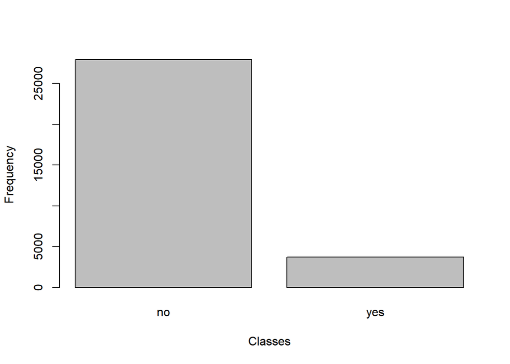

```r
barplot(table(training$class),
        xlab = "Classes", ylab = "Frequency")
```

```r
table(training_svm$class)
```

```
##
##   no  yes
## 2800  365
```

```r
prop.table(table(training_svm$class))
```

```
##
##        no       yes
## 0.8846761 0.1153239
```

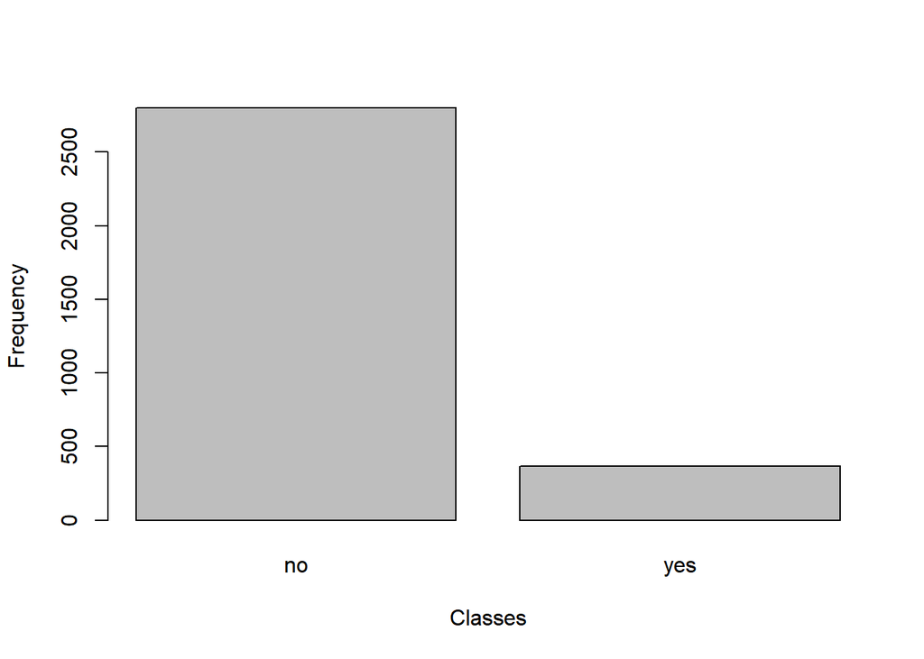

```r
barplot(table(training_svm$class),
        xlab = "Classes", ylab = "Frequency")
```

**Notes:**

- We need to figure out how to balance the sample training data in the following codes.
- And we can use F-score to choose the best ways of balancing the sample training data.

## 3.2 Building Models Without Balancing the Sample Training Data

```r
library(ROSE)
```

### 3.2.1 SVM

```r
library(e1071)
#radial for non-linear
svm_radial_1 <- svm(class~.,
                    data = training_svm,
                    kernel = "radial",
                    scale = TRUE,
                    probability = TRUE)
svm_predict_1 <- predict(svm_radial_1,
                         test_svm, probability = TRUE)
results_svm_1 <- test_svm
results_svm_1$PredictionSVM <- svm_predict_1
```

### 3.2.2 Decision Tree

```r
library(partykit)
decTree_1 <- ctree(class~.,
                   data = training)
decTree_predict_1 <- predict(decTree_1,
                             test, type="response")
results_1 <- test
results_1$PredictionTree <- decTree_predict_1
```

### 3.3.3 Naive Bayes

```r
#Naive Bayes
library(naivebayes)
naivebayes_1 <- naive_bayes(class~.,
                            data = training)
naivebayes_predict_1 <- predict(naivebayes_1,
                                test, type = "class")
results_1$PredictionNB <- naivebayes_predict_1
```

### 3.2.4 Random Forest

```r
library(randomForest)
model_RF_1 <- randomForest(class ~ .,
                           data =  training)
RF_predict_1 <- predict(model_RF_1,
                        test, type = "response")
results_1$PredictionRF <- RF_predict_1
```

```r
correct_svm_1 <- which (results_svm_1$class == results_svm_1$PredictionSVM)
length(correct_svm_1)
```

```
## [1] 1215
```

```r
correct_Tree_1 <- which(results_1$class == results_1$PredictionTree)
length(correct_Tree_1)
```

```
## [1] 12253
```

```r
correct_NB_1 <- which(results_1$class == results_1$PredictionNB)
length(correct_NB_1)
```

```
## [1] 12059
```

```r
correct_RF_1 <- which(results_1$class == results_1$PredictionRF)
length(correct_RF_1)
```

```
## [1] 12298
```

### 3.2.5 F-score of Each Model Without Balancing the Sample Training Data

```r
library(caret)
CM_DT_1 <- confusionMatrix(decTree_predict_1,
                           test$class, positive="yes")
CM_SVM_1 <- confusionMatrix(svm_predict_1,
                            test_svm$class, positive="yes")
CM_NB_1 <- confusionMatrix(naivebayes_predict_1,
                           test$class, positive="yes")
CM_RF_1 <- confusionMatrix(RF_predict_1,
                           test$class, positive="yes")
```

```r
beta <- 1
F_measure_DT_1 <- ((1 + beta^2)*CM_DT_1$byClass[5]*CM_DT_1$byClass[6])/(beta^2 * CM_DT_1$byClass[5]+CM_DT_1$byClass[6])
F_measure_SVM_1 <- ((1 + beta^2)*CM_SVM_1$byClass[5]*CM_SVM_1$byClass[6])/(beta^2 * CM_SVM_1$byClass[5]+CM_SVM_1$byClass[6])
F_measure_NB_1 <- ((1 + beta^2)*CM_NB_1$byClass[5]*CM_NB_1$byClass[6])/(beta^2 * CM_NB_1$byClass[5]+CM_NB_1$byClass[6])
F_measure_RF_1 <- ((1 + beta^2)*CM_RF_1$byClass[5]*CM_RF_1$byClass[6])/(beta^2 * CM_RF_1$byClass[5]+CM_RF_1$byClass[6])

F_measure_1 <- data.frame(DT = F_measure_DT_1,
                          SVM = F_measure_SVM_1,
                          NB = F_measure_NB_1,
                          RF = F_measure_RF_1)
row.names(F_measure_1) <- "F-measure_1"
```

## 3.3 Building Models with Both Balancing the Sample Training Data

```r
library(ROSE)
```

```r
#Both under and over -> under sample 'no' and over sample 'yes'
training_bothsampled <- ovun.sample(class~.,
                                    data = training,
                                    method = "both",
                                    p = 0.45,
                                    seed = 1)$data

table(training_bothsampled$class)
```

```
##
##    no   yes
## 17499 14148
```

```r
prop.table(table(training_bothsampled$class))
```

```
##
##        no       yes
## 0.5529434 0.4470566
```

```r
#Both under and over -> under sample 'no' and over sample 'yes'
training_svm_bothsampled <- ovun.sample(class~.,
                                        data = training_svm,
                                        method = "both",
                                        p = 0.45,
                                        seed = 1)$data

table(training_svm_bothsampled$class)
```

```
##
##   no  yes
## 1793 1372
```

```r
prop.table(table(training_svm_bothsampled$class))
```

```
##
##        no       yes
## 0.5665087 0.4334913
```

### 3.3.1 SVM

```r
library(e1071)
#radial for non-linear
svm_radial_2 <- svm(class~., data = training_svm_bothsampled,
                    kernel = "radial", scale = TRUE, probability = TRUE)
svm_predict_2 <- predict(svm_radial_2,
                         test_svm, probability = TRUE)

results_svm_2 <- test_svm
results_svm_2$PredictionSVM <- svm_predict_2
```

### 3.3.2 Decision Tree

```r
library(partykit)
decTree_2 <- ctree(class~.,
                   data = training_bothsampled)
decTree_predict_2 <- predict(decTree_2,
                             test, type="response")
results_2 <- test
results_2$PredictionTree <- decTree_predict_2
```

### 3.3.3 Naive Bayes

```r
#Naive Bayes
library(naivebayes)
naivebayes_2 <- naive_bayes(class~.,
                            data = training_bothsampled)
naivebayes_predict_2 <- predict(naivebayes_2,
                                test, type = "class")
results_2$PredictionNB <- naivebayes_predict_2
```

### 3.3.4 Random Forest

```r
library(randomForest)
model_RF_2 <- randomForest(class ~ . ,
                           data =  training_bothsampled)
RF_predict_2 <- predict(model_RF_2,
                        test, type = "response")
results_2$PredictionRF <- RF_predict_2
```

```r
correct_svm_2 <- which (results_svm_2$class == results_svm_2$PredictionSVM)
length(correct_svm_2)
```

```
## [1] 1145
```

```r
correct_Tree_2 <- which(results_2$class == results_2$PredictionTree)
length(correct_Tree_2)
```

```
## [1] 11107
```

```r
correct_NB_2 <- which(results_2$class == results_2$PredictionNB)
length(correct_NB_2)
```

```
## [1] 11134
```

```r
correct_RF_2 <- which(results_2$class == results_2$PredictionRF)
length(correct_RF_2)
```

```
## [1] 11310
```

### 3.3.5 F-score of Each Model with Both Balancing the Sample Training Data

```r
library(caret)
CM_DT_2 <- confusionMatrix(decTree_predict_2,
                           test$class, positive="yes")
CM_SVM_2 <- confusionMatrix(svm_predict_2,
                            test_svm$class, positive="yes")
CM_NB_2 <- confusionMatrix(naivebayes_predict_2,
                           test$class, positive="yes")
CM_RF_2 <- confusionMatrix(RF_predict_2,
                           test$class, positive="yes")
```

```r
beta <- 1

F_measure_DT_2 <- ((1 + beta^2)*CM_DT_2$byClass[5]*CM_DT_2$byClass[6])/(beta^2 * CM_DT_2$byClass[5]+CM_DT_2$byClass[6])

F_measure_SVM_2 <- ((1 + beta^2)*CM_SVM_2$byClass[5]*CM_SVM_2$byClass[6])/(beta^2 * CM_SVM_2$byClass[5]+CM_SVM_2$byClass[6])

F_measure_NB_2 <- ((1 + beta^2)*CM_NB_2$byClass[5]*CM_NB_2$byClass[6])/(beta^2 * CM_NB_2$byClass[5]+CM_NB_2$byClass[6])

F_measure_RF_2 <- ((1 + beta^2)*CM_RF_2$byClass[5]*CM_RF_2$byClass[6])/(beta^2 * CM_RF_2$byClass[5]+CM_RF_2$byClass[6])


F_measure_2 <- data.frame(DT = F_measure_DT_2,
                          SVM = F_measure_SVM_2,
                          NB = F_measure_NB_2,
                          RF = F_measure_RF_2)
row.names(F_measure_2) <- "F-measure_2"
```

## 3.4 Compare Models Rusults Between Both Balancing the Sample Training Data and Without Balancing the Sample Training Data

```r
F_compare <- data.frame(DT = c(F_measure_DT_1,F_measure_DT_2),
                        SVM = c(F_measure_SVM_1,F_measure_SVM_2),
                        NB = c(F_measure_NB_1,F_measure_NB_2),
                        RF = c(F_measure_RF_1,F_measure_RF_2))

row.names(F_compare) <- c("F_without", "F_both")

F_compare
```

```
##                  DT       SVM        NB        RF
## F_without 0.5062147 0.3380282 0.4568748 0.5244177
## F_both    0.5248501 0.5300668 0.4696639 0.5418699
```

**Notes:** - All models using both balancing the sample training data get higher F-score. - We continue to evalue the models based on the both balancing data in the following code.

# 4.Evaluation

## 4.1 Evaluation Metrics

```r
summary_DT <- c(CM_DT_2$overall[1], CM_DT_2$byClass[c(1,3)])
summary_SVM <- c(CM_SVM_2$overall[1], CM_SVM_2$byClass[c(1,3)])
summary_NB <- c(CM_NB_2$overall[1], CM_NB_2$byClass[c(1,3)])
summary_RF <- c(CM_RF_2$overall[1], CM_RF_2$byClass[c(1,3)])


(summary <- data.frame(DT = summary_DT,
                       SVM = summary_SVM,
                       NB = summary_NB, RF = summary_RF))
```

```
##                       DT       SVM        NB        RF
## Accuracy       0.8188587 0.8443953 0.8208493 0.8338248
## Sensitivity    0.8550725 0.7628205 0.6780088 0.8399496
## Pos Pred Value 0.3786272 0.4061433 0.3592654 0.3999400
```

```r
row.names(F_measure_2) <- "F-measure"

summary <- rbind(summary, F_measure_2)
print(summary)
```

```
##                       DT       SVM        NB        RF
## Accuracy       0.8188587 0.8443953 0.8208493 0.8338248
## Sensitivity    0.8550725 0.7628205 0.6780088 0.8399496
## Pos Pred Value 0.3786272 0.4061433 0.3592654 0.3999400
## F-measure      0.5248501 0.5300668 0.4696639 0.5418699
```

This summary shows Accuracy, Sensitivity, Pos Pred Value (precision) and F-measure of each model.

- `Accuracy` refers to the score of how well a model predicted the actual responses of customers correctly. SVM shows the highest `Accuracy` amongst the three models. However, `Accuracy` is not the sole metric to assess a model’s eligibility.
- `Sensitivity` indicates what proportion of the actual “yes” responses are predicted correctly. This ratio is important in this direct marketing case, as better prediction for the actual “yes” responses can lead to higher marketing proficiency by contacting more actual “yes” responders. In the result of the summary, Decision Tree model has the highest `Sensitivity` amongst the three.
- `Pos Pred Value` shows what proportion of the predicted “yes” responses is actual “yes”. This is also crucial ratio for this bank marketing case. This is because it is directly related to the marketing efficiency. That is, higher `Pos Pred Value` means less errors in predicting “yes” responders, which can then lower the unnecessary marketing cost of contacting actual “no” responders. According to the result, SVM has the highest `Pos Pred Value`.
- `F-measure` is the balanced metric of Pos Pred Value and Sensitivity. The result shows that SVM model has slightly higher `F-measure` than that of Decision Tree, while Naive Bayes model has relatively low `F-measure`.

According to the entire evaluation, it seems ambiguous to determine which model is the most suitable approach for selecting customers for the deposit marketing. However, sensitivity method should be considered with more weights in the direct marketing case. Due to cost-efficiency of direct marketing campaign, the costs of contacting customers will have relatively low impacts on the total expected value of the entire marketing than the profits of contacting prospective customers who will be most likely to say “yes” to the deposit offer. In other words, it is better to implement greedy direct marketing in order to obtain optimum expected value, focusing more on the profits rather than the costs. Therefore, `Decision Tree` model is determined to be the most suitable model. Even though `Decision Tree` is slightly outperformed by `SVM` and `RF` in Precision and F-measure, it has the highest Sensitivity as shown with the black dashed line of the summary figure. Therefore, `Decision Tree` model will provide more marketing benefits than the other models, which can sufficiently offset the costs of wrong direct marketing and generate more profits.

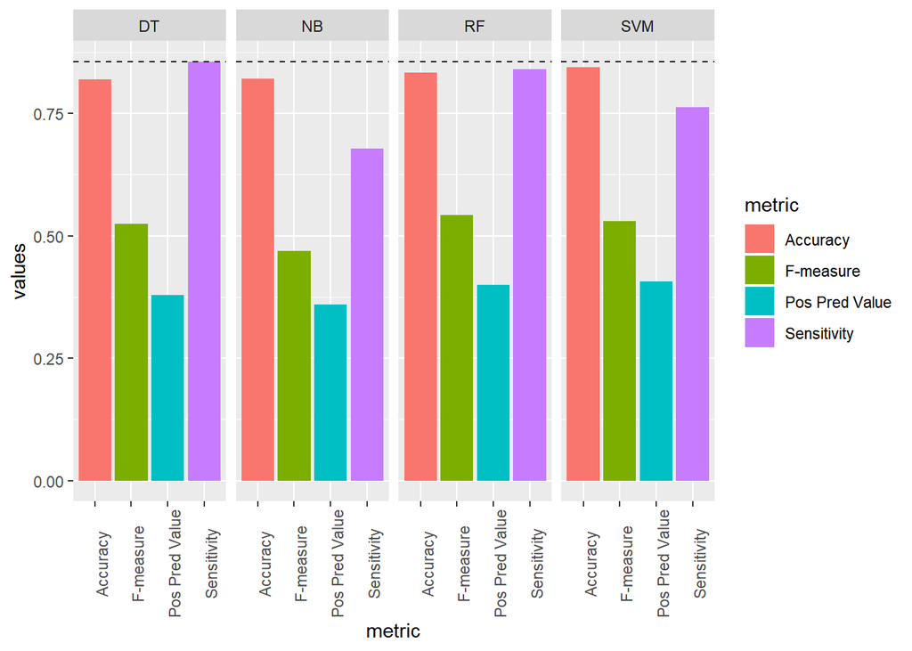

```r
summary_for_viz <- gather(summary, key="models", value = "values")
summary_for_viz <- summary_for_viz %>%
  mutate(metric = c("Accuracy", "Sensitivity",
                    "Pos Pred Value", "F-measure",
                    "Accuracy", "Sensitivity",
                    "Pos Pred Value", "F-measure",
                    "Accuracy", "Sensitivity",
                    "Pos Pred Value", "F-measure",
                    "Accuracy", "Sensitivity",
                    "Pos Pred Value", "F-measure"))

summary_for_viz$models <- as.factor(summary_for_viz$models)
summary_for_viz$metric <- as.factor(summary_for_viz$metric)

ggplot(summary_for_viz, aes(x=metric, y=values, fill = metric)) + geom_bar(stat="identity") + facet_grid(cols = vars(models)) + theme(axis.text.x = element_text(angle = 90)) + geom_hline(yintercept = summary$DT[2], col = "black", linetype = "dashed")
```

## 4.2 Receiver Operator Characteristic (ROC) Graph

- ROC curve conveys the relationship between costs of direct marketing and corresponding profits. The x-axis of the curve indicates the costs of the direct marketing and the y-axis means the profits of the direct marketing. Therefore, a better model should be the more left upper going curve, indicating higher profits with lower costs. AUC is the area under the curve.

```r
library(pROC)
prob_SVM <- attr(svm_predict_2, "probabilities")[,2]
prob_DT <- predict(decTree_2, test, type = "prob")
prob_NB <- predict(naivebayes_2, test, type="prob")
prob_RF <- predict(model_RF_2, test, type = "prob")
```

```r
ROC_SVM <- roc(class~prob_SVM, test_svm)
df_SVM <-  data.frame((1-ROC_SVM$specificities), ROC_SVM$sensitivities)
```

```r
ROC_DT <- roc(class~prob_DT[,2], test)
df_DT <- data.frame((1-ROC_DT$specificities), ROC_DT$sensitivities)
```

```r
ROC_NB <- roc(class~prob_NB[,2], test)
df_NB <- data.frame((1-ROC_NB$specificities), ROC_NB$sensitivities)
```

```r
ROC_RF <- roc(class~prob_RF[,2], test)
df_RF <- data.frame((1-ROC_RF$specificities), ROC_RF$sensitivities)
```

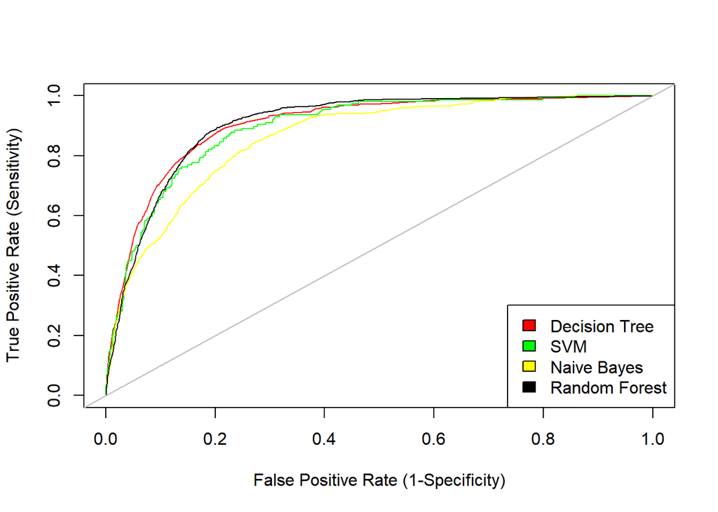

```r
plot(df_DT, col="red", type="l", xlab="False Positive Rate (1-Specificity)", ylab="True Positive Rate (Sensitivity)")
lines(df_SVM, col="green")
lines(df_NB, col="yellow")
lines(df_RF, col="black")

abline(a=0, b=1, col = "grey")

legend("bottomright",
c("Decision Tree", "SVM", "Naive Bayes", "Random Forest"),
fill=c("red", "green", "yellow", "black"))
```

```r
(AUC_DT <- auc(ROC_DT))
```

```
## Area under the curve: 0.9042
```

```r
(AUC_SVM <- auc(ROC_SVM))
```

```
## Area under the curve: 0.8925
```

```r
(AUC_NB <- auc(ROC_NB))
```

```
## Area under the curve: 0.8598
```

```r
(AUC_RF <- auc(ROC_RF))
```

```
## Area under the curve: 0.9046
```

```r
(AUC_summary <- data.frame(AUC_SVM, AUC_DT, AUC_NB, AUC_RF))
```

```
##     AUC_SVM    AUC_DT    AUC_NB    AUC_RF
## 1 0.8924599 0.9041929 0.8597964 0.9046292
```

## 4.3 Cumulative Response(Gain) Chart

- “INCREASE IN THE CORRECT PREDICTION % FOR EACH INCREASE OF INFORMATION GAIN %”

```r
library(CustomerScoringMetrics)
```

```r
GainTable_DT <- cumGainsTable(prob_DT[,2], test$class, resolution = 1/100)
GainTable_SVM <- cumGainsTable(prob_SVM, test_svm$class, resolution = 1/100)
GainTable_NB <- cumGainsTable(prob_NB[,2], test$class, resolution = 1/100)
GainTable_RF <- cumGainsTable(prob_RF[,2], test$class, resolution = 1/100)
```

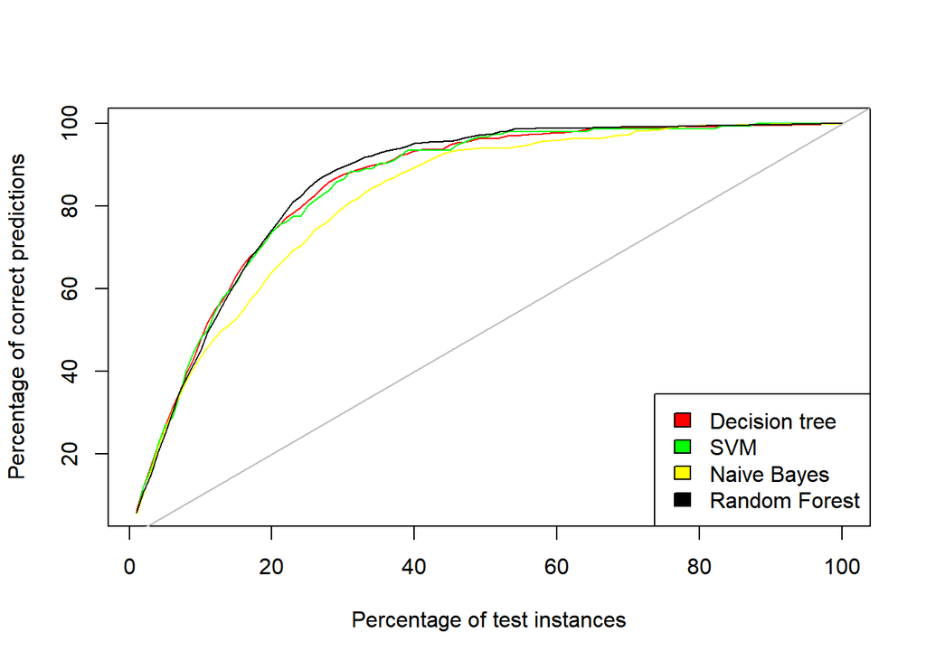

```r
plot(GainTable_DT[,4], col="red", type="l",
xlab="Percentage of test instances", ylab="Percentage of correct predictions")
lines(GainTable_SVM[,4], col="green")
lines(GainTable_NB[,4], col="yellow")
lines(GainTable_RF[,4], col="black")

abline(a = 0, b = 1, col = "grey")

legend("bottomright",
c("Decision tree", "SVM", "Naive Bayes", "Random Forest"),
fill=c("red","green", "yellow", "black"))
```